# Final Thesis

Nacho Pulido

2023-06-05

## Data mining and processing

### Load relevant libraries

Libraries *tidyverse* , *stringr*, *forcats* will be resorted to at data manipulation stage in order to deal with strings, factors and data processing. Additional libraries are required for model construction and evaluation metrics. We will also need *caret* and *MASS* to operate with our set of models and additional packages such as *httr2* or *rvest* in order to scrape some pages and gather together all available information. For further readings one can always resort to the documentation of a specific package!

```r
library(tidyverse)
library(lubridate)
library(janitor)
```

```r
library(stringr)
library(plotly)
library(ggpubr)
library(scales)
library(forcats)
library(caret)
library(readxl)
library(httr2)
library(rvest)
library(xml2)
library(tidytext)
library(MASS)
library(stargazer)
library(ggeffects)
library(pROC)
library(cluster)
library(mclust)
library(forecast)
library(tseries)
```

### Read and clean attributes

Data is read and processed in order to standardize variables and enable merging with ease at future stages. Notice that the regressor accounting for civil rights is a categorical outcome that spans from “1” (best result) to “7” (worst). Mean age was rejected in favour of a median measure to provide a more robust result and estimate values for the midpoint. For the sake of the reader, the next chunks of codes will not be run, but they supply with information on how the backgroung preprocessing was performed.

```
gdp_growth <- read.csv("C:/Users/Asus/OneDrive/Desktop/Data TFM/API_NY.GDP.PCAP.KD.ZG_DS2_en_csv_v2_4770505.csv",
         skip = 4)  %>%
  clean_names() %>%
  pivot_longer(starts_with("x"),
               names_to = "Year",
               values_to = "Gdppc_growth") %>%
  select(-contains(c("indicator"))) %>%
  mutate(Year = as.numeric(str_remove(Year,"x")))

pop_growth <- read.csv("C:/Users/Asus/OneDrive/Desktop/Data TFM/API_SP.POP.GROW_DS2_en_csv_v2_4770493.csv",
         skip = 4) %>%
  clean_names() %>%
  pivot_longer(starts_with("x"),
               names_to = "Year",
               values_to = "Pop_growth") %>%
  select(-contains(c("indicator"))) %>%
  mutate(Year = as.numeric(str_remove(Year,"x")))

continent <- read.csv("C:/Users/Asus/OneDrive/Desktop/Data TFM/continents-according-to-our-world-in-data.csv") %>%
  select(Code,Entity,Continent)

school_years <- read.csv("C:/Users/Asus/OneDrive/Desktop/Data TFM/mean-years-of-schooling-long-run.csv")
names(school_years)[4] <- "School_years"

educ_expend <- read.csv("C:/Users/Asus/OneDrive/Desktop/Data TFM/total-government-expenditure-on-education-gdp.csv")
names(educ_expend)[4] <- "Educ_expend"
educ_expend

health <- read.csv("C:/Users/Asus/OneDrive/Desktop/Data TFM/life-expectancy-vs-healthcare-expenditure.csv")
names(health)[c(4,5)] <- c("Life_expec","health_expdpc")
health <- health %>%
  select(1:5)

migration <- read.csv("C:/Users/Asus/OneDrive/Desktop/Data TFM/migration.csv") %>%
  select(contains("Net"), Year, Country) %>%
  select(c(1,3,4)) %>%
  clean_names()

Age <- read.csv("C:/Users/Asus/OneDrive/Desktop/Data TFM/median-age.csv") %>%
  select(c(1,2,3,4))
names(Age)[4] <- "Median_age"

marriage <- read.csv("C:/Users/Asus/OneDrive/Desktop/Data TFM/marriage-rate-per-1000-inhabitants.csv") %>%
  select(c(1,3,4), Code)
names(marriage)[3] <- "marriage_per_1000"

civil_rights <- read.csv("C:/Users/Asus/OneDrive/Desktop/Data TFM/civil-liberties-fh.csv") %>%
  select(c(1,3,4),Code)
names(civil_rights)[3] <- "civil_rights"
#Recall 1 is best and 7 is worst

geography <- read.csv("C:/Users/Asus/OneDrive/Desktop/Data TFM/average-latitude-longitude-countries.csv") %>%
  select(c(2,3,4))

religion <- read.csv("C:/Users/Asus/OneDrive/Desktop/Data TFM/religion.txt",
         sep = "") %>%
  select(Country, Feel) %>%
  rename("relig_feel" = "Feel")

data_sustain <- read_excel("data_sustain.xlsx")
data_sustain <- data_sustain %>%
  rename("ratio_f_m_educ" = sdg5_edat ,
         "tert_educ" = sdg4_tertiary ,
         "Code" = id )
```

### Webscraping

To work with our PISA data, we had to scrape the page and operate with the resulting HTML. We read the original link from the internet and parse it into an HTML such that we will read the 7th table from the webpage. Beware that such a webpage might be altered in a future, hence this could be another table. We transform this information into a dataframe, clean some attributes and filter for duplicated observations until we have our resulting data to be merged with the rest of databases with ease. Recall this refers to PISA observations on science exams, exclusively.

```r
link <- "https://en.wikipedia.org/wiki/Programme_for_International_Student_Assessment"
html_pisa <- link %>%
  read_html()
table <- html_pisa %>%
  html_table()
pisa <- table[7] %>%
  as.data.frame()
pisa <- pisa %>%
  slice(-c(1,2,3))
names(pisa)[2:9]<- c(rep("2015",2),rep("2012",2),rep("2009",2),rep("2006",2))
pisa <- pisa %>%
  pivot_longer(-1,names_to = "Year",values_to = "Pisa") %>%
  rename(Country = Science) %>%
  group_by(Country) %>%
  filter(!duplicated(Year)) %>%
  mutate(Pisa = str_replace(Pisa,"—",as.character(NA))) %>%
  mutate(Year = as.numeric(Year))
pisa
```

```
## # A tibble: 292 × 3
## # Groups:   Country [73]
##    Country    Year Pisa
##    <chr>     <dbl> <chr>
##  1 Albania    2015 427
##  2 Albania    2012 397
##  3 Albania    2009 391
##  4 Albania    2006 <NA>
##  5 Algeria    2015 376
##  6 Algeria    2012 <NA>
##  7 Algeria    2009 <NA>
##  8 Algeria    2006 <NA>
##  9 Argentina  2015 432
## 10 Argentina  2012 <NA>
## # … with 282 more rows
```

### Merging datasets

We take advantage of country names and years as links to *left join* our dataframes into a single R object. The final csv file is attached to the project. This is a long process oh joining all databases and standardising column names to have our data ready for manipulation and filtering.

```
df <- gdp_growth %>%
  left_join(pop_growth,
            by = c("country_name","Year","country_code")) %>%
  left_join(continent,
            by = c("country_name" = "Entity","country_code" = "Code" )) %>%
  left_join(school_years,
            by = c("country_name" = "Entity","Year","country_code" = "Code")) %>%
  left_join(educ_expend,
            by = c("country_name" = "Entity","Year","country_code" = "Code")) %>%
  left_join(health,
           by = c("country_name" = "Entity","Year","country_code" = "Code")) %>%
  left_join(migration,
            by = c("country_name" = "country","Year" = "year")) %>%
  left_join(Age,
            by = c("country_name" = "Entity","Year","country_code" = "Code")) %>%
  left_join(marriage,
            by = c("country_name" = "Entity","Year","country_code" = "Code")) %>%
  left_join(civil_rights,
            by = c("country_name" = "Entity","Year","country_code" = "Code"))%>%
  left_join(geography,
            by = c("country_name" = "Country"))%>%
  left_join(religion,
            by = c("country_name" = "Country"))%>%
  left_join(data_sustain,
            by = c("country_name" = "Country","country_code" = "Code","Year")) %>% left_join(pisa,
            by = c("country_name" = "Country","Year"))
write.csv(df,"Country_data.csv")
```

## Descriptive analysis

We open our resultant csv file to begin with our descriptive analysis. This will be key in order to understand any relationship between our attributes and to have a first approach on the impact of education on population growth rate. Our point of departure will be to read the data and build a world map accounting for differences in median age observed. We will manually add observations for the UK and USA since names were differing when working with the function *map_data*. Of course, the detailed explanations and interpretations of such operations can be read by the user in the pdf version of the project.

```r
df <- read.csv("Country_data.csv")
```

Let´s map our data:

```r
df$country_name[df$country_name == "United States"] <- "USA"
df$country_name[df$country_name == "United Kingdom"] <- "UK"
df %>%
  dplyr::select(country_name) %>%
  filter(str_detect(country_name,"Unit"))
```

```
##            country_name
## 1  United Arab Emirates
## 2  United Arab Emirates
## 3  United Arab Emirates
## 4  United Arab Emirates
## 5  United Arab Emirates
## 6  United Arab Emirates
## 7  United Arab Emirates
## 8  United Arab Emirates
## 9  United Arab Emirates
## 10 United Arab Emirates
## 11 United Arab Emirates
## 12 United Arab Emirates
## 13 United Arab Emirates
## 14 United Arab Emirates
```

[output cut: 49 more lines]

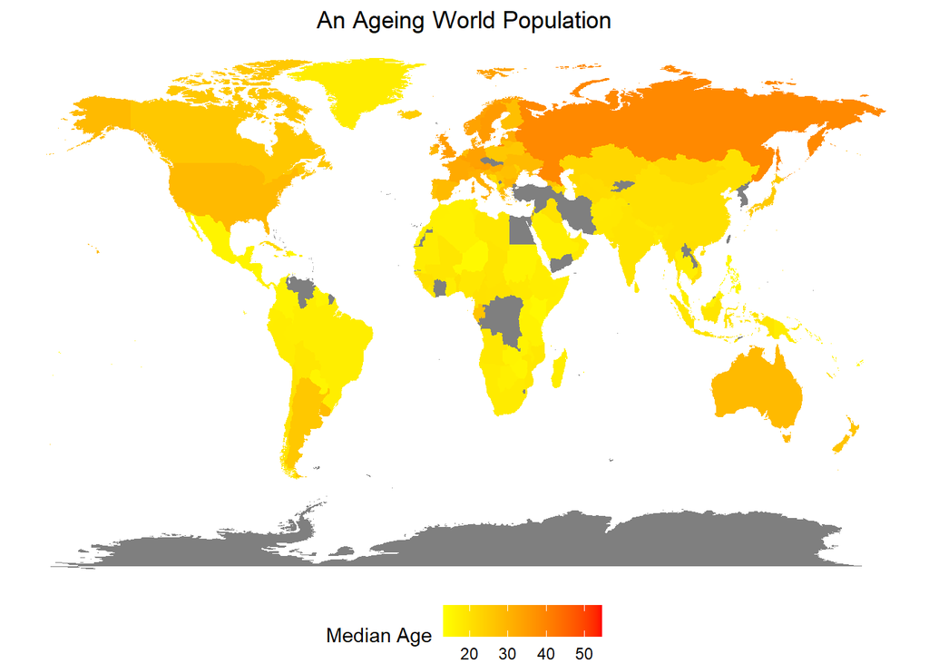

```r
map <- map_data("world") %>%
  full_join(df, by =  c("region" = "country_name"))

map$Median_age[map$region == "Russia"] <- 38.8

map %>%
  ggplot(aes(long,lat))+
  geom_polygon(aes( group = group, fill = Median_age))+
  theme_void()+
  theme(axis.title = element_blank(),
        legend.position = "bottom",
        plot.title = element_text(hjust = 0.5),
        panel.grid = element_blank())+
  labs(title = "An Ageing World Population", fill = "Median Age")+
  scale_fill_gradient(low='yellow', high= "red" )
```

Next, we will plot the relationship between population growth rate and schooling years as a first approach to notice any existing trends (negative) between education and population dynamics. We will treat years as factors since we will filter for snapshots spanning from 1975 to 2015 and include a regression line to enhance the relationship. Facets will be used to visually inspect this behaviour in each period…

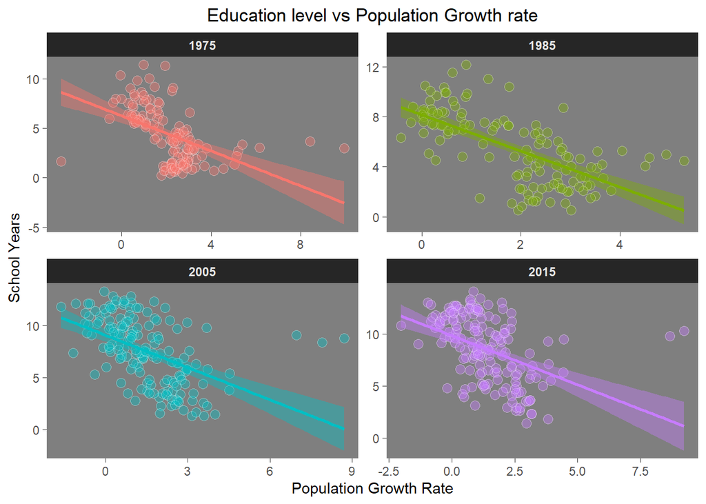

```r
df %>%
  drop_na(Pop_growth,School_years) %>%
  filter(Year %in% c(1975,1985,2005,2015)) %>%
  ggplot()+
  aes(Pop_growth,School_years, fill = as.factor(Year))+
  geom_point(shape = 21,alpha = 0.4, color = "white", size = 3)+
  geom_smooth(method = "lm", alpha = 0.4, aes(color = as.factor(Year)))+
  facet_wrap(~as.factor(Year), scales = "free")+
  theme_dark()+
  theme(panel.grid = element_blank(),
        legend.position = "none",
        strip.text = element_text(face = "bold"),
        plot.title = element_text(hjust = 0.5))+
  labs(title = "Education level vs Population Growth rate", y = "School Years", x = "Population Growth Rate")
```

Of course, this project wouldn´t make sense without having a previous understanding of the behaviour of population in each continent during the last decades. Let´s plot the evolution of population growth rate by continent by computing the mean rate observed in each of the previously defined years and faceting, this time, by continent:

```r
mean_growth <- df %>%
  drop_na(Continent) %>%
  filter(Year %in% c(1975,1980,1985,1995,2005,2015)) %>%
  group_by(Continent,Year) %>%
  summarise(var = mean(Pop_growth)) %>%
  dplyr::select(Continent, Year, var) %>%
  ungroup()
```

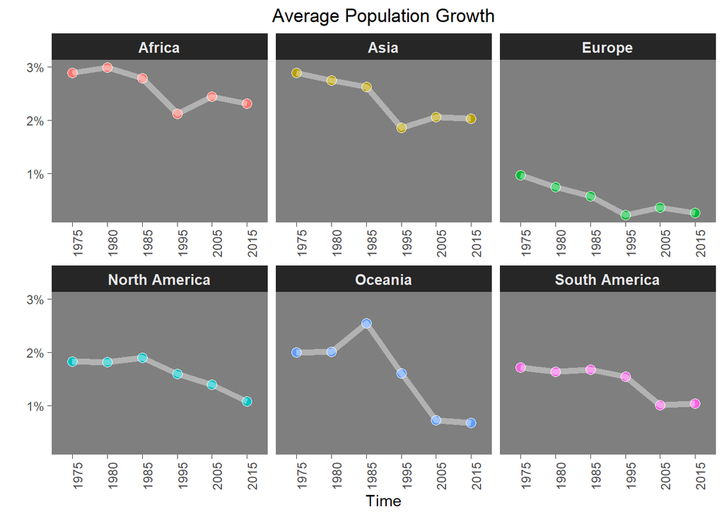

```r
mean_growth %>%
  ggplot()+
  aes(as.factor(Year),var)+
  geom_point(shape = 21, color = "white", size = 3, aes(fill = Continent))+
  geom_line(group = 1, alpha = 0.4, size = 2, color = "white")+
  facet_wrap(~Continent, scales = "free_x")+
  theme_dark()+
  theme(panel.grid = element_blank(),
        legend.position = "none",
        axis.text.x = element_text(angle = 90),
        strip.text = element_text(face = "bold", size = 10),
        plot.title = element_text(hjust = 0.5))+
  labs(title = "Average Population Growth", x = "Time", y = " ")+
  scale_y_continuous(labels = label_number(suffix = "%"))
```

The user already has a lot of information about the target variable, the current framework by continent and its relationship with school years. Another interestinf measure would be to account for the relationship between such a growth rate with median years. This will enable us to understand how an ageing population structure can influence the rate at which a population expands, and we will perform, again, a continental exploration:

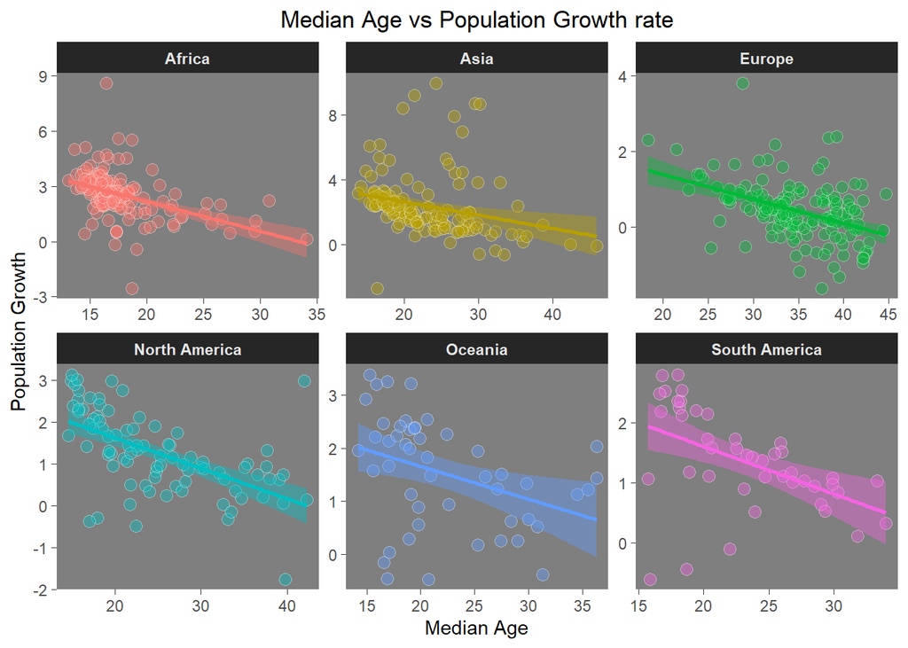

```r
df %>%
  drop_na(Pop_growth,Median_age, Life_expec) %>%
  filter(Year %in% c(1975,1985,2005,2015)) %>%
  ggplot()+
  aes(Median_age,Pop_growth, fill = Continent)+
  geom_point(shape = 21,alpha = 0.4, color = "white", size = 3)+
  geom_smooth(method = "lm",alpha = 0.4, aes(color = Continent))+
  facet_wrap(~Continent, scales = "free")+
  theme_dark()+
  theme(panel.grid = element_blank(),
        legend.position = "none",
        strip.text = element_text(face = "bold"),
        plot.title = element_text(hjust = 0.5))+
  labs(title = "Median Age vs Population Growth rate", y = "Population Growth", x = "Median Age")
```

Is education a good indicator of academic performance? We will answer this question by constructing a new variable measuring the interaction between education expenditure and number of school years and evaluate this impact on PISA results. Notice only a small number of countries are subject to such tests, so we have much less observations for these, but we still observe a quite stron relationship:

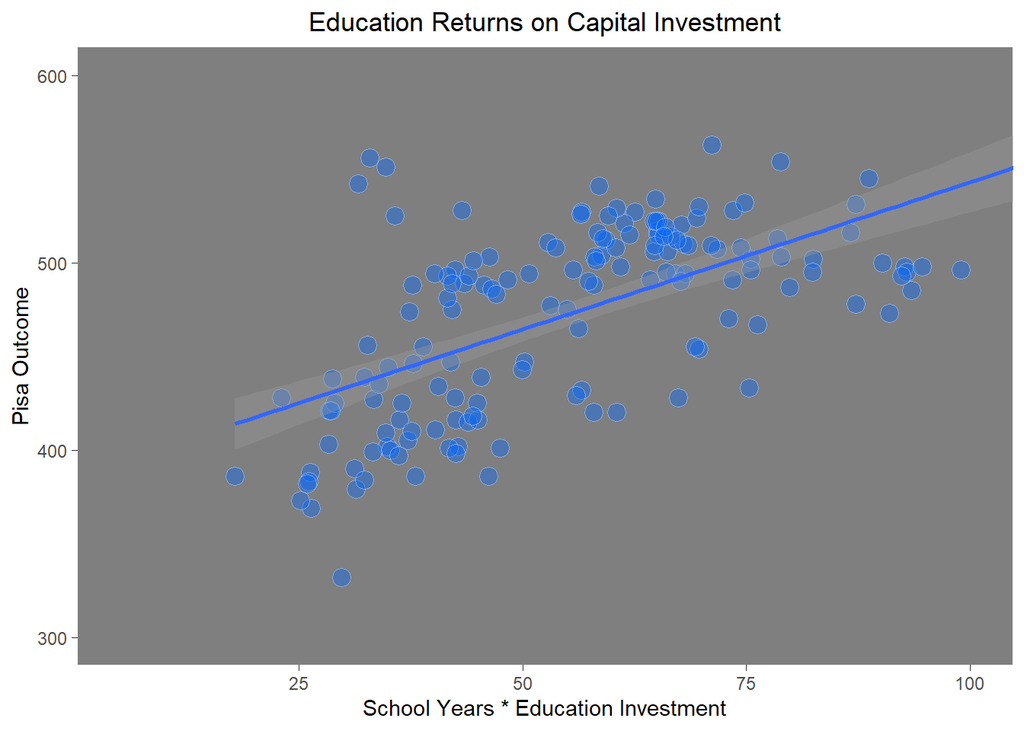

```r
df %>%
  mutate(inter = Educ_expend*School_years) %>%
  ggplot()+
  aes(inter,Pisa)+
  geom_point(shape = 21, size = 4, alpha = 0.4, color = "white", fill = rgb(0,0.4,1))+
  theme_classic()+
  geom_smooth(method = "lm")+
  theme_dark()+
  theme(panel.grid = element_blank(),
        plot.title = element_text(hjust = 0.5))+
  labs(x = "School Years * Education Investment", y = "Pisa Outcome", title = "Education Returns on Capital Investment")+
  coord_cartesian(xlim = c(5,100), ylim = c(300,600))
```

One could have an interest in exploring the relationship between our civil rights variable, the magnitude of religious significance the economy is experiencing and the percentage of women in tertiary education as a ratio to men. It is important to add variables measuring women performance and inclusion because we want to study effects on population, tightly linked to fertility rates, so women are the main characters in this analysis:

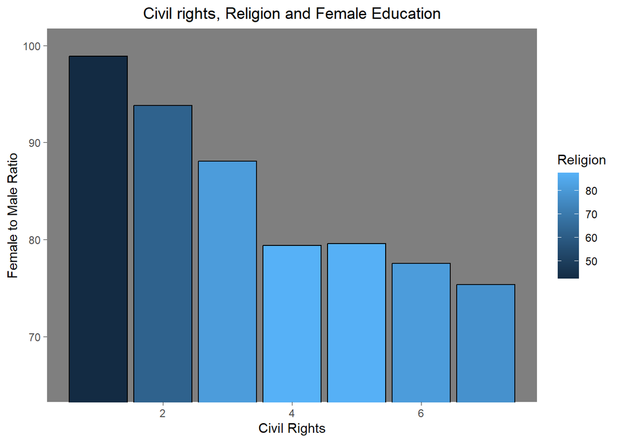

```r
df %>%
  group_by(civil_rights) %>%
  summarise(female_ratio = mean(ratio_f_m_educ,na.rm = TRUE),
            Religion = mean(relig_feel, na.rm = TRUE)) %>%
  drop_na(civil_rights) %>%
  ggplot()+
  aes(civil_rights,female_ratio, fill = Religion)+
  geom_bar(stat = "identity", color = "black")+
  coord_cartesian(ylim = c(65,100))+
  theme_dark()+
  theme(panel.grid = element_blank(),
        plot.title = element_text(hjust = 0.5))+
  labs(title = "Civil rights, Religion and Female Education", y = "Female to Male Ratio", x = "Civil Rights")
```

Let´s explore the relationship between migration rate and population growth. We observe a positive trend (as one could expect) portraying some heteroscedasticity for extreme migration observations:

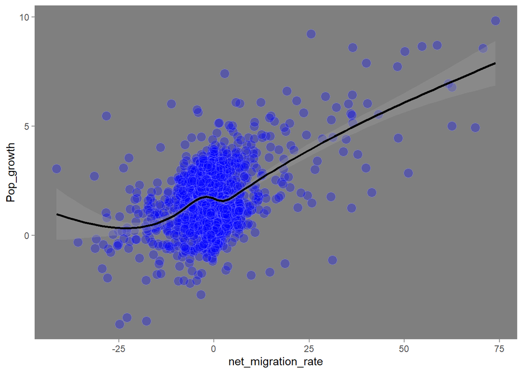

```r
df %>%
  drop_na(Continent) %>%
  filter(Pop_growth < 10, Pop_growth> -7) %>%
  filter(net_migration_rate < 75, net_migration_rate > -50) %>%
  ggplot()+
  aes(net_migration_rate,Pop_growth)+
  geom_point(shape = 21, color = "white", alpha = 0.3, fill = "blue", size = 4)+
  geom_smooth(color = "black")+
  theme_dark()+
 theme(panel.grid = element_blank(),
        plot.title = element_text(hjust = 0.5))
```

## Feature engineering

Now we have complete information for each of our economies and by year. However, we will have to perform many transformations and devote some time for inspection and feature engineering if we want to operate with this data (We have NA´s, categorical variables, years without information etc).

### Interaction terms

We will begin by performing an ANOVA test for the interaction term between continent and civil rights on population growth. These variables,both by themseleves and interacted, seem to be relevant in explaining the behaviour of population growth rate since we observe a p-value almost negligible. In an ANOVA test, if the between variation is greater than the within variation in each group, we reject the null and consider some statistical differences. This means we will have to include such interaction term at the modelling stage.

```r
data <- df
my_anova <- aov(Pop_growth ~ Continent*civil_rights, data)
summary(my_anova)
```

```
##                          Df Sum Sq Mean Sq F value   Pr(>F)
## Continent                 5   5367  1073.4  453.76  < 2e-16 ***
## civil_rights              1    112   112.5   47.55 5.79e-12 ***
## Continent:civil_rights    5    189    37.8   15.96 1.11e-15 ***
## Residuals              7694  18200     2.4
## ---
## Signif. codes:  0 '***' 0.001 '**' 0.01 '*' 0.05 '.' 0.1 ' ' 1
## 9052 observations deleted due to missingness
```

Let´s explore the effect of interaction terms between our attributes and school years. To do this, we will select numeric variables and generate a new dataframe in which we will apply a function which crosses all columns with schooling years. Next, we will calculate the correlation between such variable and population growth for all variables and append this information at the end in a single data frame:

```r
data_new <-
  data %>%
  dplyr::select(where(is.numeric)) %>%
           dplyr::select(-c(1,2,4,5))
inter <- data_new %>%
  mutate(across(everything(),function(x) x*data$School_years))
inter$Pop_growth <- data$Pop_growth
a <- inter %>%
  drop_na(Pop_growth,Educ_expend) %>%
  dplyr::select(Pop_growth,Educ_expend) %>%
  cor()
b <- inter %>%
  drop_na(Pop_growth,Life_expec) %>%
  dplyr::select(Pop_growth,Life_expec) %>%
  cor()
c <- inter %>%
  drop_na(Pop_growth,Pisa) %>%
  dplyr::select(Pop_growth,Pisa) %>%
  cor()
d <- inter %>%
  drop_na(Pop_growth,health_expdpc) %>%
  dplyr::select(Pop_growth,health_expdpc) %>%
  cor()
f <- inter %>%
  drop_na(Pop_growth,net_migration_rate) %>%
  dplyr::select(Pop_growth,net_migration_rate) %>%
  cor()
g <- inter %>%
  drop_na(Pop_growth,Median_age) %>%
  dplyr::select(Pop_growth,Median_age) %>%
  cor()
h <- inter %>%
  drop_na(Pop_growth,marriage_per_1000) %>%
  dplyr::select(Pop_growth,marriage_per_1000) %>%
  cor()
i  <- inter %>%
  drop_na(Pop_growth,ratio_f_m_educ) %>%
  dplyr::select(Pop_growth,ratio_f_m_educ) %>%
  cor()
j <- inter %>%
  drop_na(Pop_growth,tert_educ) %>%
  dplyr::select(Pop_growth,tert_educ) %>%
  cor()
k <- inter %>%
  drop_na(Pop_growth,Gdppc_growth) %>%
  dplyr::select(Pop_growth,Gdppc_growth) %>%
  cor()
correlation_inter <- rbind(a,b,c,d,f,g,h,i,j,k) %>%
  as.data.frame() %>%
  dplyr::select(Pop_growth) %>%
  rename(Correlation_inter = Pop_growth) %>%
  slice(seq(2,20,2))
correlation_inter <- correlation_inter %>%
  mutate(Variable = rownames(correlation_inter))
```

We enter this information into ggplot and build our correlation plots in terms of interactions with school years. This will be a tool for us to enable the comparison in terms of correlation between the variable by itself and crossing it with schooling years:

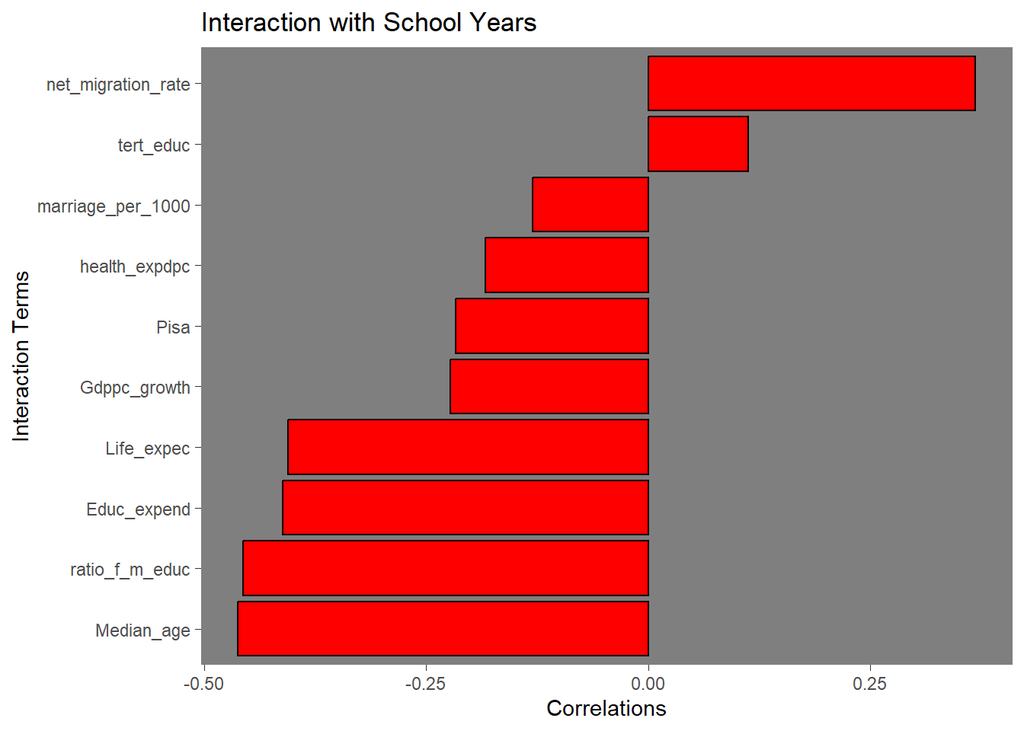

```r
correlation_inter %>%
  ggplot() +
  aes(Correlation_inter,reorder(Variable,Correlation_inter))+
  geom_bar(stat = "identity", color = "black", fill = "red")+
  theme_dark()+
  theme(panel.grid = element_blank())+
  labs(title = "Interaction with School Years",
       y = "Interaction Terms",
       x = "Correlations")
```

### Correlative analysis, Power transformations

Let´s perform the analogous analysis for the amount of correlation of each variable by itself with the target variable:

```r
a <- data %>%
  drop_na(Pop_growth,Educ_expend) %>%
  dplyr::select(Pop_growth,Educ_expend) %>%
  cor()
b <- data %>%
  drop_na(Pop_growth,Life_expec) %>%
  dplyr::select(Pop_growth,Life_expec) %>%
  cor()
c <- data %>%
  drop_na(Pop_growth,Pisa) %>%
  dplyr::select(Pop_growth,Pisa) %>%
  cor()
d <- data %>%
  drop_na(Pop_growth,health_expdpc) %>%
  dplyr::select(Pop_growth,health_expdpc) %>%
  cor()
e <- data %>%
  drop_na(Pop_growth,School_years) %>%
  dplyr::select(Pop_growth,School_years) %>%
  cor()
f <- data %>%
  drop_na(Pop_growth,net_migration_rate) %>%
  dplyr::select(Pop_growth,net_migration_rate) %>%
  cor()
g <- data %>%
  drop_na(Pop_growth,Median_age) %>%
  dplyr::select(Pop_growth,Median_age) %>%
  cor()
h <- data %>%
  drop_na(Pop_growth,marriage_per_1000) %>%
  dplyr::select(Pop_growth,marriage_per_1000) %>%
  cor()
i  <-data %>%
  drop_na(Pop_growth,ratio_f_m_educ) %>%
  dplyr::select(Pop_growth,ratio_f_m_educ) %>%
  cor()
j <-data %>%
  drop_na(Pop_growth,tert_educ) %>%
  dplyr::select(Pop_growth,tert_educ) %>%
  cor()
k <- data %>%
  drop_na(Pop_growth,Gdppc_growth) %>%
  dplyr::select(Pop_growth,Gdppc_growth) %>%
  cor()
correlation <- rbind(a,b,c,d,e,f,g,h,i,j,k) %>%
  as.data.frame() %>%
  dplyr::select(Pop_growth) %>%
  rename(Correlation = Pop_growth) %>%
  slice(seq(2,22,2))
correlation <- correlation %>%
  mutate(Variable = rownames(correlation))
```

We pipe this results into *ggplot* and set the identity stat on our geometry. The theme selected will be the same as for our previous plot. We can already notice that those variables holding the highest magnitude of positive correlation with population growth rate are migration rate and marriage whereas the most relevant ones in terms of negative association are median age and school years. The ratio of female to male people in tertiary education hold a very high correlation coefficient of almost -0.4!

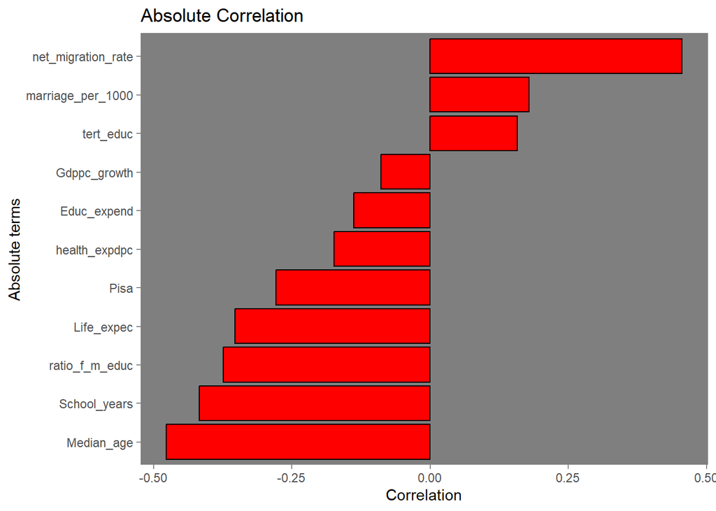

```r
correlation %>%
  ggplot() +
  aes(Correlation,reorder(Variable,Correlation))+
  geom_bar(stat = "identity", color = "black", fill = "red")+
  theme_dark()+
  theme(panel.grid = element_blank())+
  labs(y = "Absolute terms", x = "Correlation",
       title = "Absolute Correlation")
```

Let´s perform the same anaylisis for power terms by generating a function which squares the value. This function will be applied to every numeric attribute in our data and we will compute the amount of correlation between each variable and population growth rate:

```r
square <- function(x){
  x^2
}
data_sq <- data %>%
  dplyr::select(where(is.numeric), -c(X,Year,Pop_growth)) %>%
  mutate(across(everything(),square))
data_sq$Pop_growth <- data$Pop_growth
a <- data_sq %>%
  drop_na(Pop_growth,Educ_expend) %>%
  dplyr::select(Pop_growth,Educ_expend) %>%
  cor()
b <- data_sq %>%
  drop_na(Pop_growth,Life_expec) %>%
  dplyr::select(Pop_growth,Life_expec) %>%
  cor()
c <- data_sq %>%
  drop_na(Pop_growth,Pisa) %>%
  dplyr::select(Pop_growth,Pisa) %>%
  cor()
d <- data_sq %>%
  drop_na(Pop_growth,health_expdpc) %>%
  dplyr::select(Pop_growth,health_expdpc) %>%
  cor()
e <- data_sq %>%
  drop_na(Pop_growth,School_years) %>%
  dplyr::select(Pop_growth,School_years) %>%
  cor()
f <- data_sq %>%
  drop_na(Pop_growth,net_migration_rate) %>%
  dplyr::select(Pop_growth,net_migration_rate) %>%
  cor()
g <- data_sq %>%
  drop_na(Pop_growth,Median_age) %>%
  dplyr::select(Pop_growth,Median_age) %>%
  cor()
h <- data_sq %>%
  drop_na(Pop_growth,marriage_per_1000) %>%
  dplyr::select(Pop_growth,marriage_per_1000) %>%
  cor()
i  <-data_sq %>%
  drop_na(Pop_growth,ratio_f_m_educ) %>%
  dplyr::select(Pop_growth,ratio_f_m_educ) %>%
  cor()
j <-data_sq %>%
  drop_na(Pop_growth,tert_educ) %>%
  dplyr::select(Pop_growth,tert_educ) %>%
  cor()
k <- data_sq %>%
  drop_na(Pop_growth,Gdppc_growth) %>%
  dplyr::select(Pop_growth,Gdppc_growth) %>%
  cor()
correlation_sq <- rbind(a,b,c,d,e,f,g,h,i,j,k) %>%
  as.data.frame() %>%
  dplyr::select(Pop_growth) %>%
  rename(Correlation_sq = Pop_growth) %>%
  slice(seq(2,22,2))
correlation_sq <- correlation_sq %>%
  mutate(Variable = rownames(correlation_sq))
```

As usual, we enter this information into ggplot:

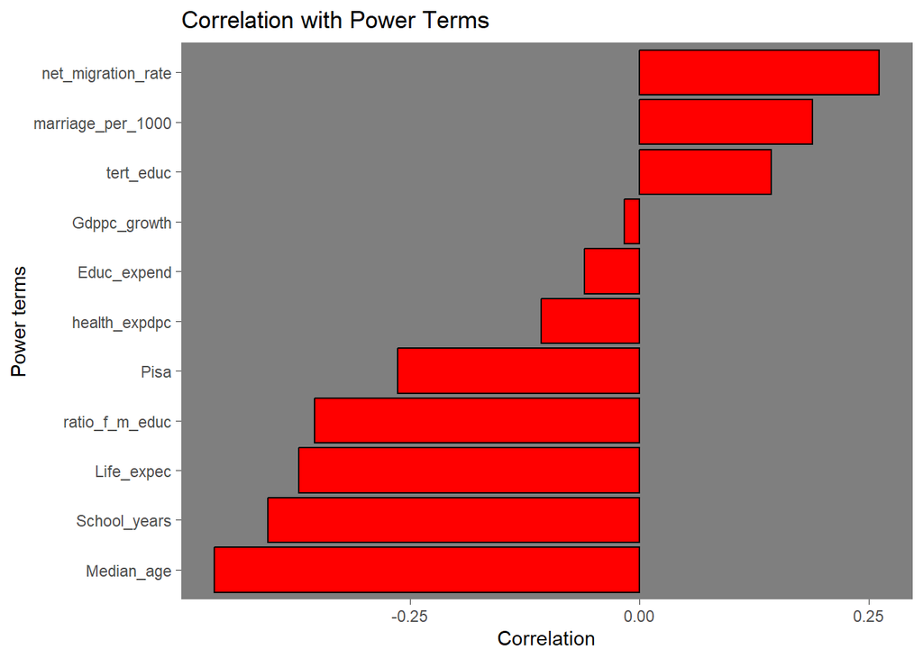

```r
correlation_sq %>%
  ggplot() +
  aes(Correlation_sq,reorder(Variable,Correlation_sq))+
  geom_bar(stat = "identity", color = "black", fill = "red")+
  theme_dark()+
  theme(panel.grid = element_blank())+
  labs(y = "Power terms",
       x = "Correlation",
       title = "Correlation with Power Terms")
```

### Visualizing the Matrix

By comparing the magnitude of these correlations, we have determined that it is imperative to include a squared term for both life expectancy and marriage in combination with joint effects for education expenditure, life expectancy, and female to male ratio on tertiary education. Our study also calls for logarithmic features for many of our variables, which is a common technique in economics when accounting for growth rates and for the sake of avoiding heteroscedastic issues.

```r
fet_engin <- cbind(correlation,correlation_sq) %>%
  dplyr::select(-2) %>%
  left_join(correlation_inter, by = "Variable") %>%
  dplyr::select(Variable,Correlation,Correlation_sq,Correlation_inter)

fet_engin %>%
  filter(abs(Correlation_sq)>abs(Correlation))
```

```
##            Variable Correlation Correlation_sq Correlation_inter
## 1        Life_expec  -0.3526155     -0.3712851        -0.4053839
## 2 marriage_per_1000   0.1790867      0.1883669        -0.1303997
```

```r
#square term on life expectancy and marriage relevant

fet_engin %>%
  filter(abs(Correlation_inter)>abs(Correlation))
```

```
##         Variable Correlation Correlation_sq Correlation_inter
## 1    Educ_expend -0.13741328    -0.06019242        -0.4109146
## 2     Life_expec -0.35261546    -0.37128513        -0.4053839
## 3  health_expdpc -0.17364971    -0.10672003        -0.1828424
## 4 ratio_f_m_educ -0.37337207    -0.35400395        -0.4558863
## 5   Gdppc_growth -0.08852419    -0.01683746        -0.2228272
```

## Multiple Imputation

One of our main concerns at the data manipulation and encoding stage was the substantial number of missing values stemming from database merging, time measurement inconsistencies or absence of full public disclosure in some cases. Let´s generate two dataframes computing the number of missing observations in each column for data previous 1980 and beyond. To do this, we will use the *is.na* operator, add the results for each vector and divide the outcome by the total number of rows in our data:

```r
df <- data
missing_1 <- df %>%
  is.na() %>%
  colSums() %>%
  as.data.frame() %>%
  rename(Missing = ".") %>%
  mutate(Percentage = Missing/nrow(df),
         Attribute = as.vector(names(df)))
```

We operate analogously by filtering for data starting in 1980:

```r
missing_2 <- df %>%
  filter(Year > 1979) %>%
  is.na() %>%
  colSums() %>%
  as.data.frame() %>%
  rename(Missing = ".") %>%
  mutate(Percentage = Missing/nrow(df),
         Attribute = as.vector(names(df)))
```

We will build a slightly more advanced plot in which we will attach one graph in front of the other to visually explore the differences in missing observations with and without filtering. This illustration is an advocate for the fundamental decision of restricting the sample period to the one proposed:

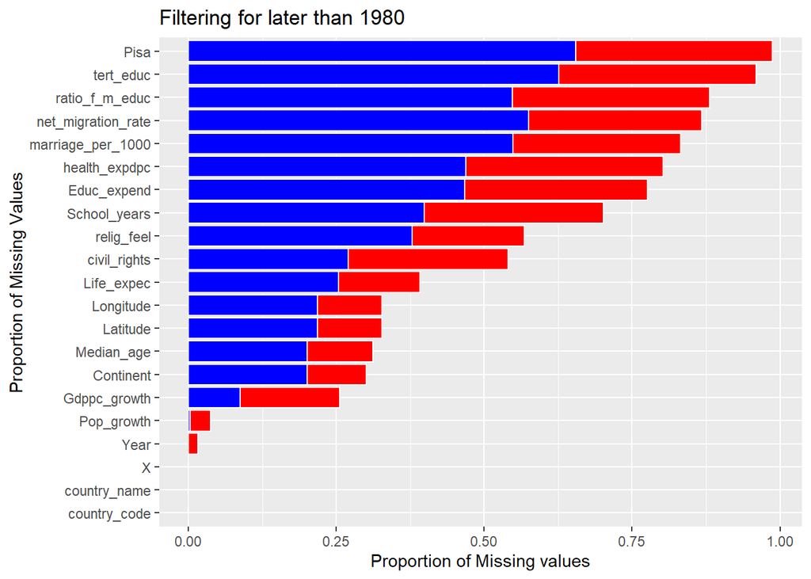

```r
missing_1 %>%
  ggplot()+
  aes(Percentage, reorder(Attribute,Percentage))+
  geom_bar(stat = "identity", color = "white", fill = "red")+
  geom_bar(aes(Percentage, Attribute),data = missing_2, fill = "Blue", stat = "identity", color = "white")+
  labs(x = "Proportion of Missing values", title = "Filtering for later than 1980", y = "Proportion of Missing Values")
```

Hence, let´s filter the results from now on from 1980 onwards:

```r
df <-
  df %>%
  filter(Year > 1979)
```

### School Years

The choice of the best fitting imputation technique is a sound approach based on the visualization of the distribution before and after imputation which enables the analyst to discriminate within algorithms and establish which technique preserves the original characteristics of the data. We will impute missing observations for some of our variables (the ones with more percentage of missing observations) and select the algorithm yielding the best outcome. We begin with school years (please, notice this takes a while):

```r
library(mice)
mice_imputed <- data.frame(
  original = df$School_years,
  imputed_pmm = complete(mice(df, m=5, method = "pmm"))$School_years,
  imputed_cart = complete(mice(df, m=5, method = "cart"))$School_years,
  imputed_lasso = complete(mice(df, m=5, method = "lasso.norm"))$School_years
)
```

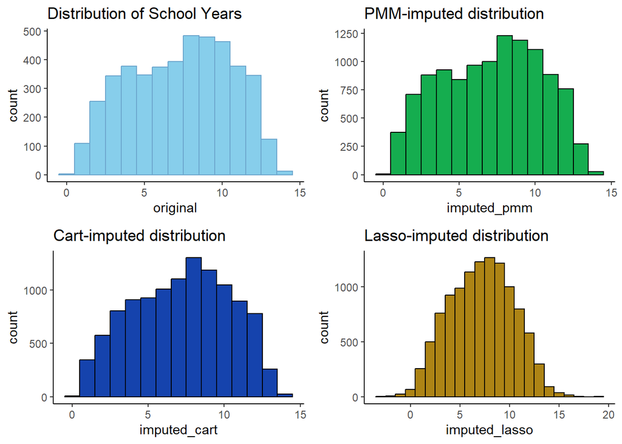

```r
h1 <- ggplot(mice_imputed, aes(x = original)) +
  geom_histogram(binwidth = 1, color = "skyblue3", fill = "skyblue") +
  ggtitle("Distribution of School Years") +
  theme_classic()
h2 <- ggplot(mice_imputed, aes(x = imputed_pmm)) +
  geom_histogram(binwidth = 1, fill = "#15ad4f", color = "#000000", position = "identity") +
  ggtitle("PMM-imputed distribution") +
  theme_classic()
h3 <- ggplot(mice_imputed, aes(x = imputed_cart)) +
  geom_histogram(binwidth = 1, fill = "#1543ad", color = "#000000", position = "identity") +
  ggtitle("Cart-imputed distribution") +
  theme_classic()
h4 <- ggplot(mice_imputed, aes(x = imputed_lasso)) +
  geom_histogram(binwidth = 1, fill = "#ad8415", color = "#000000", position = "identity") +
  ggtitle("Lasso-imputed distribution") +
  theme_classic()

ggarrange(h1,h2,h3,h4)
```

As a final step, we replace these values in the original dataframe:

```r
df$School_years <- mice_imputed$imputed_pmm
```

### Life Expectancy

We perform the same for the variable on life expectancy…

```r
mice_imputed <- data.frame(
  original = df$Life_expec,
  imputed_pmm = complete(mice(df, m=5, method = "pmm"))$Life_expec,
  imputed_cart = complete(mice(df, m=5, method = "cart"))$Life_expec,
  imputed_lasso = complete(mice(df, m=5, method = "lasso.norm"))$Life_expec
)
```

Visually inspect the most appropriate distribution:

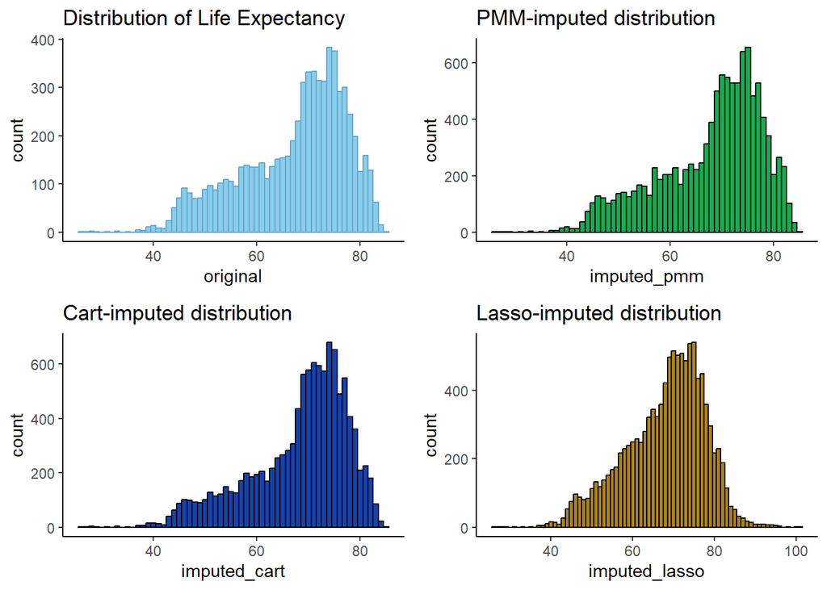

```r
h1 <- ggplot(mice_imputed, aes(x = original)) +
  geom_histogram(binwidth = 1, color = "skyblue3", fill = "skyblue") +
  ggtitle("Distribution of Life Expectancy") +
  theme_classic()
h2 <- ggplot(mice_imputed, aes(x = imputed_pmm)) +
  geom_histogram(binwidth = 1, fill = "#15ad4f", color = "#000000", position = "identity") +
  ggtitle("PMM-imputed distribution") +
  theme_classic()
h3 <- ggplot(mice_imputed, aes(x = imputed_cart)) +
  geom_histogram(binwidth = 1, fill = "#1543ad", color = "#000000", position = "identity") +
  ggtitle("Cart-imputed distribution") +
  theme_classic()
h4 <- ggplot(mice_imputed, aes(x = imputed_lasso)) +
  geom_histogram(binwidth = 1, fill = "#ad8415", color = "#000000", position = "identity") +
  ggtitle("Lasso-imputed distribution") +
  theme_classic()

ggarrange(h1,h2,h3,h4)
```

Replace the original values in the corresponding data column:

```r
df$Life_expec <- mice_imputed$imputed_pmm
```

### Net Migration Rate

Same for net migration rate:

```r
mice_imputed <- data.frame(
  original = df$net_migration_rate,
  imputed_pmm = complete(mice(df, m=5, method = "pmm"))$net_migration_rate,
  imputed_cart = complete(mice(df, m=5, method = "cart"))$net_migration_rate,
  imputed_lasso = complete(mice(df, m=5, method = "lasso.norm"))$net_migration_rate
)
```

Again, compare the different distributions obtained:

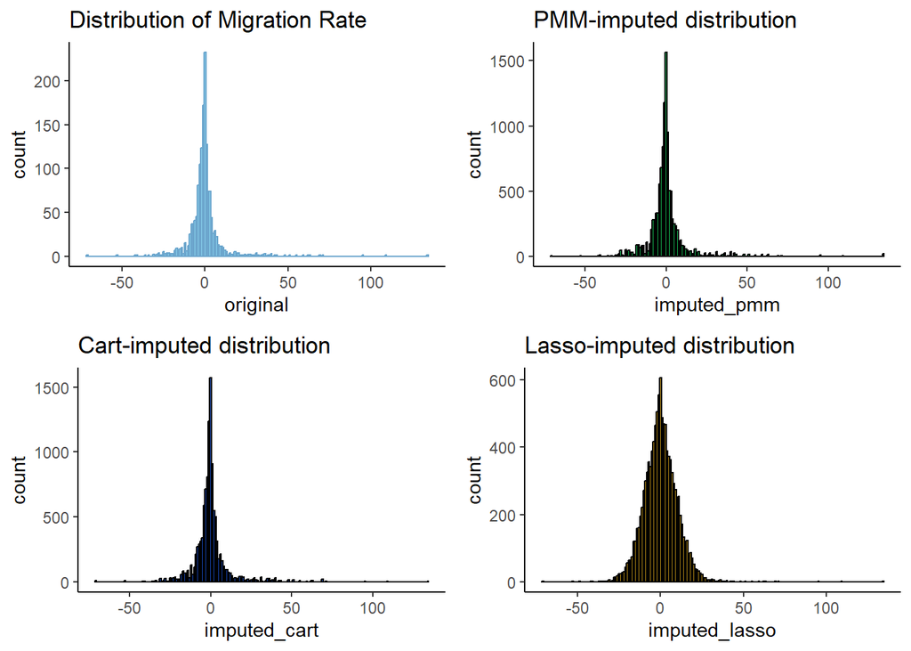

```r
h1 <- ggplot(mice_imputed, aes(x = original)) +
  geom_histogram(binwidth = 1, color = "skyblue3", fill = "skyblue") +
  ggtitle("Distribution of Migration Rate") +
  theme_classic()
h2 <- ggplot(mice_imputed, aes(x = imputed_pmm)) +
  geom_histogram(binwidth = 1, fill = "#15ad4f", color = "#000000", position = "identity") +
  ggtitle("PMM-imputed distribution") +
  theme_classic()
h3 <- ggplot(mice_imputed, aes(x = imputed_cart)) +
  geom_histogram(binwidth = 1, fill = "#1543ad", color = "#000000", position = "identity") +
  ggtitle("Cart-imputed distribution") +
  theme_classic()
h4 <- ggplot(mice_imputed, aes(x = imputed_lasso)) +
  geom_histogram(binwidth = 1, fill = "#ad8415", color = "#000000", position = "identity") +
  ggtitle("Lasso-imputed distribution") +
  theme_classic()

ggarrange(h1,h2,h3,h4)
```

Once we have selected the best imputation algorithm, we replace the original data with it. Notice that, in this case, we are resorting to the “cart” procedure.

```r
df$net_migration_rate <- mice_imputed$imputed_cart
```

### Female to Male Ratio

For the case of female to male ratio in tertiary education:

```r
mice_imputed <- data.frame(
  original = df$ratio_f_m_educ,
  imputed_pmm = complete(mice(df, m=5, method = "pmm"))$ratio_f_m_educ,
  imputed_cart = complete(mice(df, m=5, method = "cart"))$ratio_f_m_educ,
  imputed_lasso = complete(mice(df, m=5, method = "lasso.norm"))$ratio_f_m_educ
)
```

We plot the results arising from the different algorithms:

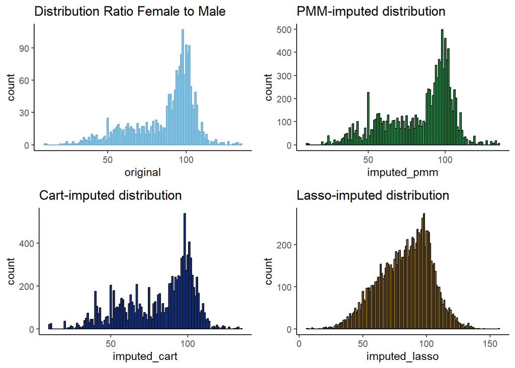

```r
h1 <- ggplot(mice_imputed, aes(x = original)) +
  geom_histogram(binwidth = 1, color = "skyblue3", fill = "skyblue") +
  ggtitle("Distribution Ratio Female to Male") +
  theme_classic()
h2 <- ggplot(mice_imputed, aes(x = imputed_pmm)) +
  geom_histogram(binwidth = 1, fill = "#15ad4f", color = "#000000", position = "identity") +
  ggtitle("PMM-imputed distribution") +
  theme_classic()
h3 <- ggplot(mice_imputed, aes(x = imputed_cart)) +
  geom_histogram(binwidth = 1, fill = "#1543ad", color = "#000000", position = "identity") +
  ggtitle("Cart-imputed distribution") +
  theme_classic()
h4 <- ggplot(mice_imputed, aes(x = imputed_lasso)) +
  geom_histogram(binwidth = 1, fill = "#ad8415", color = "#000000", position = "identity") +
  ggtitle("Lasso-imputed distribution") +
  theme_classic()

ggarrange(h1,h2,h3,h4)
```

Replace our results in the original dataframe we will perform the same for the rest of variables, this might get a bit boring for the reader, one can always skip this and directly move to the next section in which we gather all these steps together in a single csv!

```r
df$ratio_f_m_educ <- mice_imputed$imputed_cart
```

### Marriage

Marriage is imputed:

```r
mice_imputed <- data.frame(
  original = df$marriage_per_1000,
  imputed_pmm = complete(mice(df, m=5, method = "pmm"))$marriage_per_1000,
  imputed_cart = complete(mice(df, m=5, method = "cart"))$marriage_per_1000,
  imputed_lasso = complete(mice(df, m=5, method = "lasso.norm"))$marriage_per_1000
)
```

The imputed distributions are plotted and visually compared:

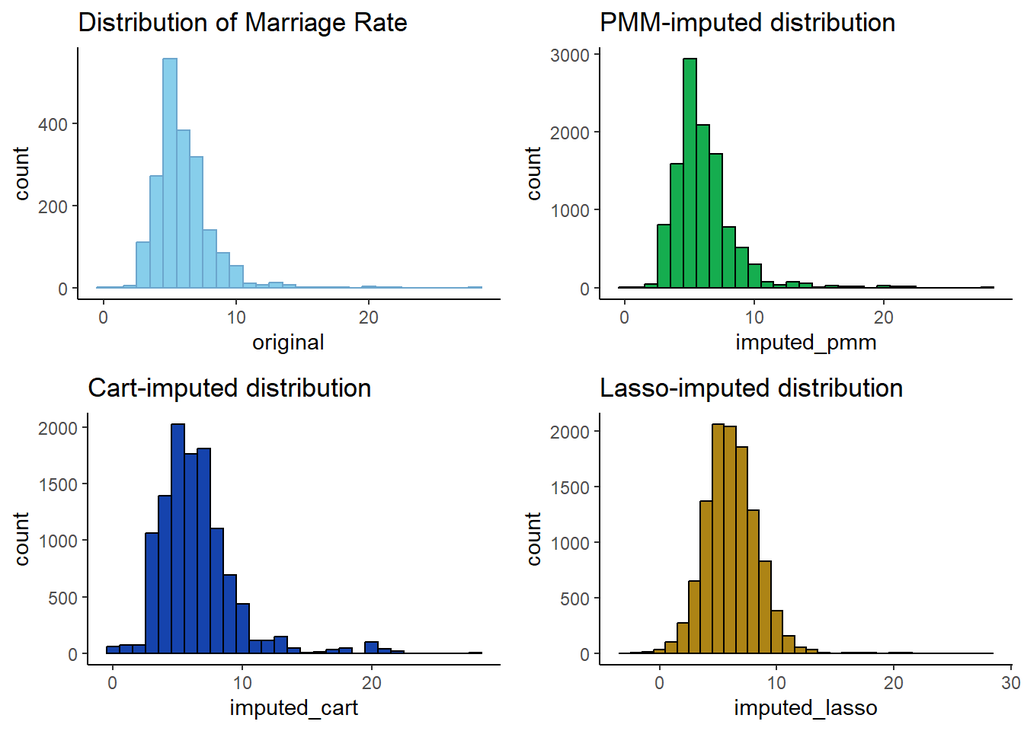

```r
h1 <- ggplot(mice_imputed, aes(x = original)) +
  geom_histogram(binwidth = 1, color = "skyblue3", fill = "skyblue") +
  ggtitle("Distribution of Marriage Rate") +
  theme_classic()
h2 <- ggplot(mice_imputed, aes(x = imputed_pmm)) +
  geom_histogram(binwidth = 1, fill = "#15ad4f", color = "#000000", position = "identity") +
  ggtitle("PMM-imputed distribution") +
  theme_classic()
h3 <- ggplot(mice_imputed, aes(x = imputed_cart)) +
  geom_histogram(binwidth = 1, fill = "#1543ad", color = "#000000", position = "identity") +
  ggtitle("Cart-imputed distribution") +
  theme_classic()
h4 <- ggplot(mice_imputed, aes(x = imputed_lasso)) +
  geom_histogram(binwidth = 1, fill = "#ad8415", color = "#000000", position = "identity") +
  ggtitle("Lasso-imputed distribution") +
  theme_classic()

ggarrange(h1,h2,h3,h4)
```

```r
df$marriage_per_1000 <- mice_imputed$imputed_pmm
```

### Education Expenditure

Same for education expenditure…

```r
mice_imputed <- data.frame(
  original = df$Educ_expend,
  imputed_pmm = complete(mice(df, m=5, method = "pmm"))$Educ_expend,
  imputed_cart = complete(mice(df, m=5, method = "cart"))$Educ_expend,
  imputed_lasso = complete(mice(df, m=5, method = "lasso.norm"))$Educ_expend
)
```

We plot the imputed results of education expenditure. This variable was a bit more difficult to impute because it had great variability and portrayed some outliers:

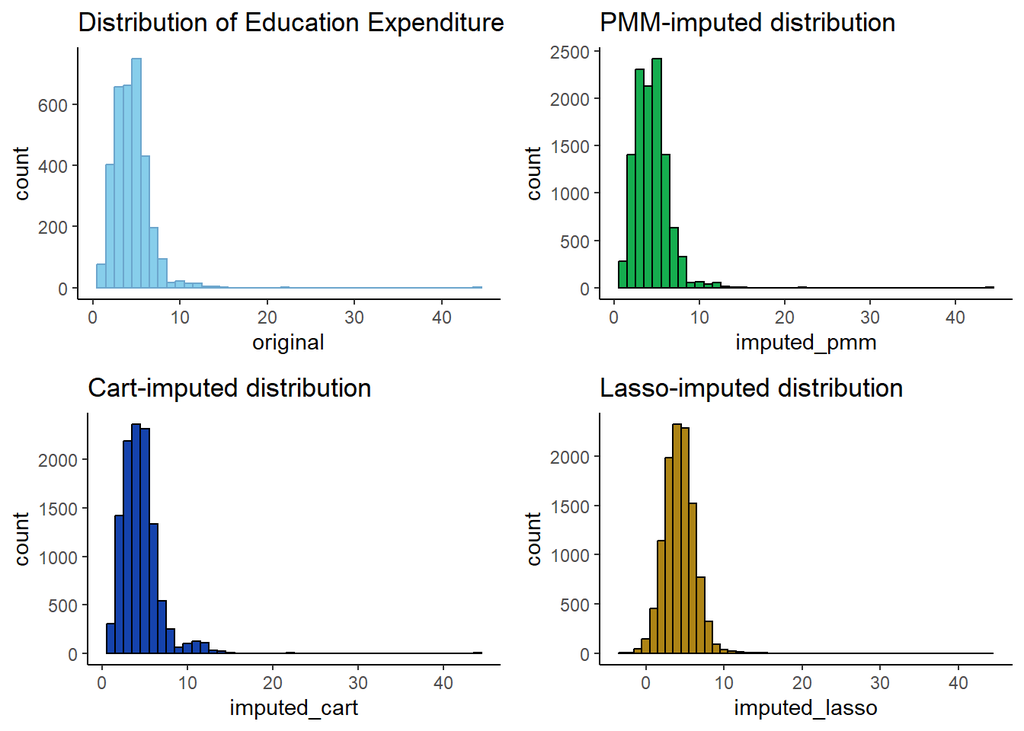

```r
h1 <- ggplot(mice_imputed, aes(x = original)) +
  geom_histogram(binwidth = 1, color = "skyblue3", fill = "skyblue") +
  ggtitle("Distribution of Education Expenditure") +
  theme_classic()
h2 <- ggplot(mice_imputed, aes(x = imputed_pmm)) +
  geom_histogram(binwidth = 1, fill = "#15ad4f", color = "#000000", position = "identity") +
  ggtitle("PMM-imputed distribution") +
  theme_classic()
h3 <- ggplot(mice_imputed, aes(x = imputed_cart)) +
  geom_histogram(binwidth = 1, fill = "#1543ad", color = "#000000", position = "identity") +
  ggtitle("Cart-imputed distribution") +
  theme_classic()
h4 <- ggplot(mice_imputed, aes(x = imputed_lasso)) +
  geom_histogram(binwidth = 1, fill = "#ad8415", color = "#000000", position = "identity") +
  ggtitle("Lasso-imputed distribution") +
  theme_classic()

ggarrange(h1,h2,h3,h4)
```

```r
df$Educ_expend <- mice_imputed$imputed_pmm
```

### Health Expenditure

We impute in the same way our health dimension (expenditure):

```r
mice_imputed <- data.frame(
  original = df$health_expdpc,
  imputed_pmm = complete(mice(df, m=5, method = "pmm"))$health_expdpc,
  imputed_cart = complete(mice(df, m=5, method = "cart"))$health_expdpc,
  imputed_lasso = complete(mice(df, m=5, method = "lasso.norm"))$health_expdpc
)
```

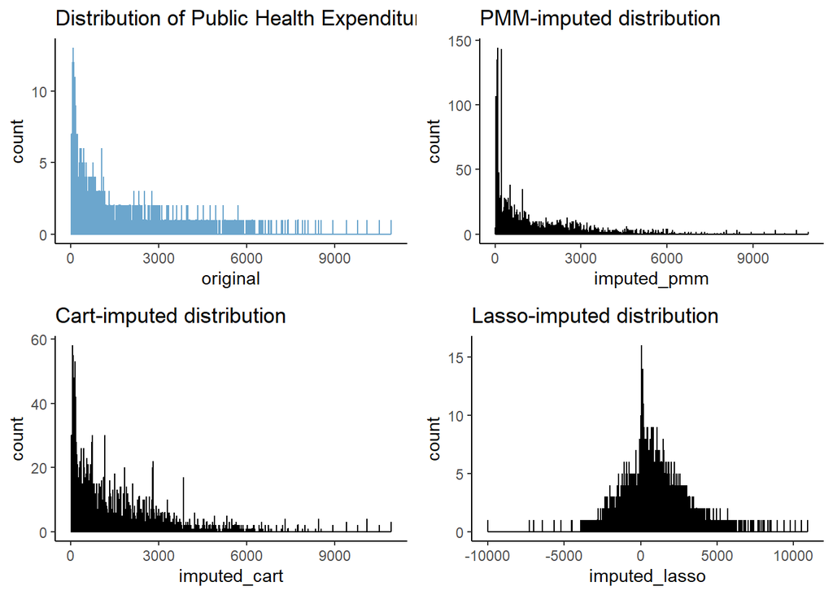

```r
h1 <- ggplot(mice_imputed, aes(x = original)) +
  geom_histogram(binwidth = 1, color = "skyblue3", fill = "skyblue") +
  ggtitle("Distribution of Public Health Expenditure") +
  theme_classic()
h2 <- ggplot(mice_imputed, aes(x = imputed_pmm)) +
  geom_histogram(binwidth = 1, fill = "#15ad4f", color = "#000000", position = "identity") +
  ggtitle("PMM-imputed distribution") +
  theme_classic()
h3 <- ggplot(mice_imputed, aes(x = imputed_cart)) +
  geom_histogram(binwidth = 1, fill = "#1543ad", color = "#000000", position = "identity") +
  ggtitle("Cart-imputed distribution") +
  theme_classic()
h4 <- ggplot(mice_imputed, aes(x = imputed_lasso)) +
  geom_histogram(binwidth = 1, fill = "#ad8415", color = "#000000", position = "identity") +
  ggtitle("Lasso-imputed distribution") +
  theme_classic()

ggarrange(h1,h2,h3,h4)
```

This was one of the cases in which we preferred the “cart” algorithm.

```r
df$health_expdpc <- mice_imputed$imputed_cart
```

### Median Age

Median age was one of the variables with fewer proportion of missing observations, but we will manage this values anyway:

```r
library(mice)
mice_imputed <- data.frame(
  original = df$Median_age,
  imputed_pmm = complete(mice(df, m=5, method = "pmm"))$Median_age,
  imputed_cart = complete(mice(df, m=5, method = "cart"))$Median_age,
  imputed_lasso = complete(mice(df, m=5, method = "lasso.norm"))$Median_age
)
```

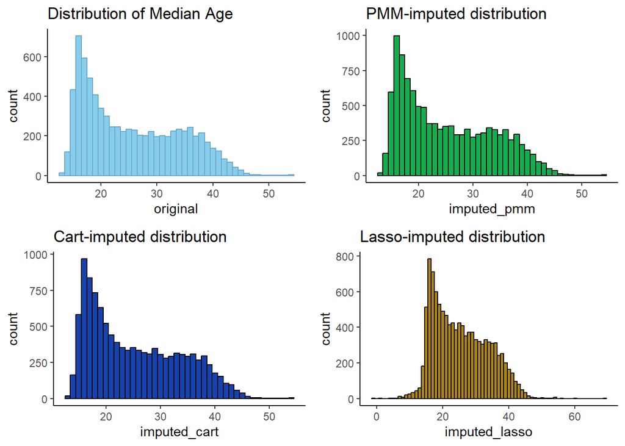

```r
h1 <- ggplot(mice_imputed, aes(x = original)) +
  geom_histogram(binwidth = 1, color = "skyblue3", fill = "skyblue") +
  ggtitle("Distribution of Median Age") +
  theme_classic()
h2 <- ggplot(mice_imputed, aes(x = imputed_pmm)) +
  geom_histogram(binwidth = 1, fill = "#15ad4f", color = "#000000", position = "identity") +
  ggtitle("PMM-imputed distribution") +
  theme_classic()
h3 <- ggplot(mice_imputed, aes(x = imputed_cart)) +
  geom_histogram(binwidth = 1, fill = "#1543ad", color = "#000000", position = "identity") +
  ggtitle("Cart-imputed distribution") +
  theme_classic()
h4 <- ggplot(mice_imputed, aes(x = imputed_lasso)) +
  geom_histogram(binwidth = 1, fill = "#ad8415", color = "#000000", position = "identity") +
  ggtitle("Lasso-imputed distribution") +
  theme_classic()

ggarrange(h1,h2,h3,h4)
```

Replace these results in the original dataframe:

```r
df$Median_age <- mice_imputed$imputed_cart
```

### Tertiary Education

On the other hand, the percentage of people in tertiary education had one of the greatest percentage of missing observations, which calls for the introduction of our imputation techniques:

```r
mice_imputed <- data.frame(
  original = df$tert_educ,
  imputed_pmm = complete(mice(df, m=5, method = "pmm"))$tert_educ,
  imputed_cart = complete(mice(df, m=5, method = "cart"))$tert_educ,
  imputed_lasso = complete(mice(df, m=5, method = "lasso.norm"))$tert_educ
)
```

We analyse carefully each of the distributions:

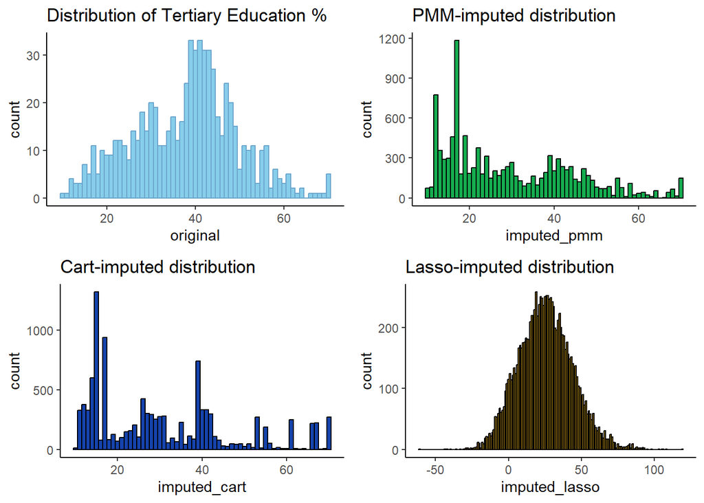

```r
h1 <- ggplot(mice_imputed, aes(x = original)) +
  geom_histogram(binwidth = 1, color = "skyblue3", fill = "skyblue") +
  ggtitle("Distribution of Tertiary Education %") +
  theme_classic()
h2 <- ggplot(mice_imputed, aes(x = imputed_pmm)) +
  geom_histogram(binwidth = 1, fill = "#15ad4f", color = "#000000", position = "identity") +
  ggtitle("PMM-imputed distribution") +
  theme_classic()
h3 <- ggplot(mice_imputed, aes(x = imputed_cart)) +
  geom_histogram(binwidth = 1, fill = "#1543ad", color = "#000000", position = "identity") +
  ggtitle("Cart-imputed distribution") +
  theme_classic()
h4 <- ggplot(mice_imputed, aes(x = imputed_lasso)) +
  geom_histogram(binwidth = 1, fill = "#ad8415", color = "#000000", position = "identity") +
  ggtitle("Lasso-imputed distribution") +
  theme_classic()

ggarrange(h1,h2,h3,h4)
```

```r
df$tert_educ <- mice_imputed$imputed_pmm
```

### Civil Rights

We operate the same with civil rights. Recall this variable is defined as a categorical one ranging from 1 to 7 in which 1 is the best and 7 refers to countries with extremely low levels of individual freedom.

```r
mice_imputed <- data.frame(
  original = df$civil_rights,
  imputed_pmm = complete(mice(df, m=5, method = "pmm"))$civil_rights,
  imputed_cart = complete(mice(df, m=5, method = "cart"))$civil_rights,
  imputed_lasso = complete(mice(df, m=5, method = "lasso.norm"))$civil_rights
)
```

We compare the distribution of all imputed values:

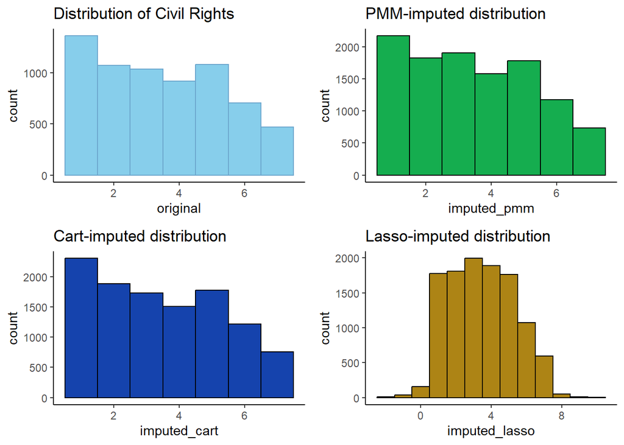

```r
h1 <- ggplot(mice_imputed, aes(x = original)) +
  geom_histogram(binwidth = 1, color = "skyblue3", fill = "skyblue") +
  ggtitle("Distribution of Civil Rights") +
  theme_classic()
h2 <- ggplot(mice_imputed, aes(x = imputed_pmm)) +
  geom_histogram(binwidth = 1, fill = "#15ad4f", color = "#000000", position = "identity") +
  ggtitle("PMM-imputed distribution") +
  theme_classic()
h3 <- ggplot(mice_imputed, aes(x = imputed_cart)) +
  geom_histogram(binwidth = 1, fill = "#1543ad", color = "#000000", position = "identity") +
  ggtitle("Cart-imputed distribution") +
  theme_classic()
h4 <- ggplot(mice_imputed, aes(x = imputed_lasso)) +
  geom_histogram(binwidth = 1, fill = "#ad8415", color = "#000000", position = "identity") +
  ggtitle("Lasso-imputed distribution") +
  theme_classic()

ggarrange(h1,h2,h3,h4)
```

```r
df$civil_rights <- mice_imputed$imputed_cart
```

### Missing Continents: Inspection

As an additional section on the imputation stage, some continent attributes were lost (likely due to merging of the different soruces) and we manually recover these values by replacing inside the continent column, in the place where the country name matches with the selected query, the appropriate continent they belong to:

```r
df$Continent[df$country_name == "Channel Islands"] <- "Europe"
df$Continent[df$country_name == "Congo, Rep."] <- "Africa"
df$Continent[df$country_name == "Cabo Verde"] <- "Africa"
df$Continent[df$country_name == "Gambia, The"] <- "Africa"
df$Continent[df$country_name == "Korea, Rep."] <- "Asia"
df$Continent[df$country_name == "Slovak Republic"] <- "Europe"
```

We can now save these results inside a new csv:

```r
write.csv(df,"Clean_data.csv")
```

## Feature Generation

We will now devote a section to generate all the attributes we developed at the feature engineering stage. This step is important because it will be key to improve the performance of our models and capture non linear trends in the data.

```r
data <- read.csv("Clean_data.csv")
```

We first generate the square terms by mutating across life expectancy and marriage and applying our square function.

```r
squares <- data %>%
  mutate(across(c(Life_expec,marriage_per_1000),square)) %>%
  dplyr::select(Life_expec_sq = Life_expec,marriage_per_1000_sq = marriage_per_1000)
```

For the interaction terms, we will cross each attribute with school years and select the remaining variables. Recall this will be applied to gdp growth rate, education expenditure, life expectancy and our female to male ratio in education.

```r
interactions <-
  data %>%
  mutate(educexp_schlyrs = Educ_expend*School_years,
         lifexp_schlyrs = Life_expec*School_years,
         ratio_fm_schlyrs = ratio_f_m_educ*School_years,
         gdp_schlyrs = Gdppc_growth*School_years) %>%
  dplyr::select(educexp_schlyrs,lifexp_schlyrs,ratio_fm_schlyrs,gdp_schlyrs)
```

Our study also calls for logarithmic features for many of our variables, which is a common technique in economics when accounting for growth rates and for the sake of avoiding heteroscedastic issues. In future sections, we plan to perform an automated feature selection method to further refine our model and improve its predictive power.

```r
logs <-
  data %>%
  mutate(lg_Median_age = log(Median_age),
         lg_health_expdpc = log(health_expdpc),
         lg_Life_expec = log(Life_expec),
         lg_ratio_fm = log(ratio_f_m_educ),
         lg_Educ_expend = log(Educ_expend),
         lg_Gdppc_growth = log(Gdppc_growth+65)) %>%
  dplyr::select(starts_with("lg"))
```

We append this information together inside the same dataframe and save it.

```r
data <- cbind(data,logs,interactions,squares)
```

```r
write.csv(data,"final_data.csv")
```

## Lasso regression

At this stage, we will apply our feature selection algorithms in order to discard redundant variables and improve the performance of the model. If we include too many variables, we are likely to incur in multicollinearity issues which can lead to overfitting our model and worsen the performance at the testing stage.

We drop missing observations of population growth rate and remove unnecessary variables such as country name.

```r
data <- read.csv("final_data.csv")
data <- data %>%
  drop_na(Pop_growth)


data <-data %>%
 dplyr::select(-(starts_with("X")|starts_with("country")),-c(Year,Pisa,Longitude,Latitude))
```

## Winzorization

We had noticed at earlier stages of the project the fact that we have many outliers. With some trial and error, we have determined that by applying some winzorisation techniques and replacing those extreme observations by the 98th and 3rd percentile, the performance of our models is enhanced:

```r
lower_bound <- quantile(data$Pop_growth,probs = 0.03)
upper_bound <- quantile(data$Pop_growth,probs = 0.98)

data$Pop_growth[data$Pop_growth > upper_bound] <- upper_bound

data$Pop_growth[data$Pop_growth < lower_bound] <- lower_bound
```

We split our data into training and testing set to perform our machine learning algorithms.

```r
set.seed(123)
training_samples <- data$Pop_growth %>%
  createDataPartition(p = 0.7, list = FALSE)

train_data <- data %>%
  slice(training_samples)

test_data <- data %>%
  slice(-training_samples)
```

We will resort to cross validation with 6 folds and set the corresponding hyperparameter for lasso regression. This process is iterated k times (each fold used once for validation) and the performance of each model is evaluated based on our predefined performance metrics until the hyperparameters outputting the best realization are designated for the final process.

```r
set.seed(123)
train_data <-
  train_data %>%
  drop_na()

ctrl <- trainControl(method = "repeatedcv",
                     number = 6,
                     verboseIter = T)

lasso_grid <- expand.grid(fraction = seq(0.1, 0.5, length = 100))

lasso_tune <- train(Pop_growth ~ . + Continent*civil_rights + Continent*School_years - Continent, data = train_data,
                    method='lasso',
                    preProc=c('scale','center'),
                    tuneGrid = lasso_grid,
                    trControl=ctrl)
best <- as.numeric(lasso_tune$bestTune)

predict(lasso_tune$finalModel, type = "coeff", mode = "fraction", s = best)
```

```
## $s
## [1] 0.4313131
##
## $fraction
##         0
## 0.4313131
##
## $mode
## [1] "fraction"
##
## $coefficients
##                        Gdppc_growth                        School_years
##                        -0.110248212                        -0.275597308
##                         Educ_expend                          Life_expec
##                        -0.141755961                         0.000000000
##                       health_expdpc                  net_migration_rate
##                         0.172784102                         0.406907173
##                          Median_age                   marriage_per_1000
##                         0.000000000                        -0.028884541
##                        civil_rights                          relig_feel
##                        -0.043012590                         0.071114442
##                      ratio_f_m_educ                           tert_educ
##                        -0.131281493                         0.065683507
##                       lg_Median_age                    lg_health_expdpc
##                        -1.302035519                         0.081286130
##                       lg_Life_expec                         lg_ratio_fm
##                         0.043364644                        -0.007409031
##                      lg_Educ_expend                     lg_Gdppc_growth
##                         0.047201305                         0.064706044
##                     educexp_schlyrs                      lifexp_schlyrs
##                         0.093488640                         0.052669371
##                    ratio_fm_schlyrs                         gdp_schlyrs
##                         0.181085849                         0.030866091
##                       Life_expec_sq                marriage_per_1000_sq
##                         0.172130759                         0.043838697
##          ContinentAsia:civil_rights        ContinentEurope:civil_rights
##                         0.022641752                        -0.059328168
## ContinentNorth America:civil_rights       ContinentOceania:civil_rights
##                        -0.094635810                         0.018171465
## ContinentSouth America:civil_rights          ContinentAsia:School_years
##                        -0.003645652                        -0.005199475
##        ContinentEurope:School_years ContinentNorth America:School_years
##                        -0.043415681                         0.019498419
##       ContinentOceania:School_years ContinentSouth America:School_years
##                         0.000000000                        -0.033801550
```

Let´s plot the results of the optimized Lasso hyperparameter in terms of the R-squared. The R-squared measures the amount of correlation observed between the predicted values and actual observations.

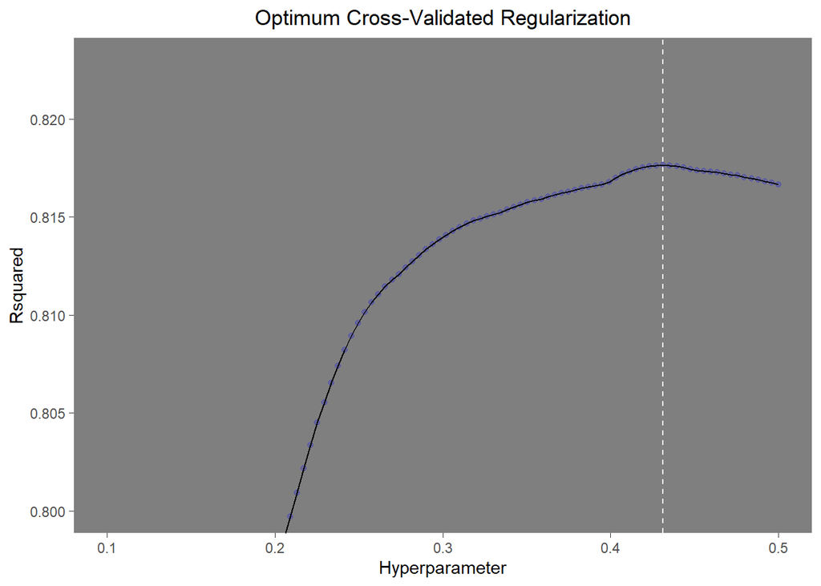

```r
regularization <- lasso_tune$results %>%
  ggplot()+
  aes(fraction,Rsquared)+
  theme_dark()+
  geom_point(fill = "blue", color = "blue", alpha = 0.2)+
  theme(panel.grid = element_blank(),
        plot.title = element_text(hjust = 0.5))+
  geom_vline(xintercept = best, color = "white", linetype = 2)+
  labs(title = "Optimum Cross-Validated Regularization",
       x = "Hyperparameter")+
  geom_line()+
  coord_cartesian(ylim = c(0.8,0.823))

regularization
```

```r
ggsave("regular_plot.png", regularization)
```

## Ridge Regression

Ridge regression is different from Lasso in the sense that the penalization introduced is calculated with the square of the coefficients of the linear model. We train our ridge regression and compare the results with the previous model. We will also explore the best tune of this model:

```r
ridge_grid <- expand.grid(lambda = seq(0, .1, length = 100))

ridge_tune <- train(Pop_growth ~ . + Continent*civil_rights + Continent*School_years - Continent , data = train_data,
                    method='ridge',
                    preProc=c('scale','center'),
                    tuneGrid = ridge_grid,
                    trControl=ctrl)
ridge_tune$bestTune
```

```
##        lambda
## 20 0.01919192
```

## Elastic Net

The parameter λ accounts for the penalty introduced for the inclusion of parameters and this will behave as a hyperparameter such that we will resort to cross-validation to find the optimal solution for this measure. As the parameter increases, the penalty introduced is higher and, therefore, in lasso regression it can happen that some parameters are brought completely to 0 (null). Elastic net will be a combination of the lasso and ridge mechanisms called before.

```r
set.seed(123)
elastic_grid = expand.grid(alpha = seq(0, .2, 0.01), lambda = seq(0, .1, 0.01))

glmnet_tune <- train(Pop_growth ~ . + Continent*civil_rights + Continent*School_years - Continent, data = train_data,
                     method='glmnet',
                     tuneGrid = elastic_grid,
                     trControl=ctrl)
glmnet_tune$bestTune
```

```
##     alpha lambda
## 145  0.13   0.01
```

```r
table <- as.data.frame(as.matrix(predict(glmnet_tune$finalModel, type = "coeff", mode = "lambda", s = 0.1))) %>%
  mutate(regularized = ifelse(s1 == 0, "Regularized",
                              "Fitting"))

write.csv(table, "elasticnet.txt")
```

### Model Selection

Our criteria will depend both on the R-squared and a qualitative side (more detailed explanations are included in the pdf version of the project):

```r
test_data <-
  test_data %>%
  drop_na()
preds_lasso <- lasso_tune %>%
  predict(test_data,type = "raw")
(cor(preds_lasso,test_data$Pop_growth))^2
```

```
## [1] 0.7868399
```

Let´s compute the R-squared for our ridge regression by calculating the correlation between our predictions and actual observations and square this term.

```r
preds_ridge <- ridge_tune %>%
  predict(test_data,type = "raw")
(cor(preds_ridge,test_data$Pop_growth))^2
```

```
## [1] 0.7817872
```

Compute the R-squared value for the elastic net model:

```r
preds_glmnet <-  glmnet_tune %>%
  predict(test_data,type = "raw")
round((cor(preds_glmnet,test_data$Pop_growth))^2,2)
```

```
## [1] 0.78
```

## Multiple Linear Model

```r
final_model <- train(Pop_growth ~ . + Continent*civil_rights + Continent*School_years - Continent - Life_expec_sq - civil_rights - educexp_schlyrs - Life_expec - lg_ratio_fm -lifexp_schlyrs - marriage_per_1000_sq - lg_Gdppc_growth - lg_Educ_expend - lg_health_expdpc, data = train_data,
                     preProc=c('scale','center'),
                     method='lm',
                     trControl=ctrl)
summary(final_model)
```

```
##
## Call:
## lm(formula = .outcome ~ ., data = dat)
##
## Residuals:
##     Min      1Q  Median      3Q     Max
## -3.3507 -0.2401 -0.0001  0.2313  3.1249
##
## Coefficients:
##                                        Estimate Std. Error t value Pr(>|t|)
## (Intercept)                            1.562640   0.009931 157.347  < 2e-16 ***
## Gdppc_growth                          -0.044618   0.020950  -2.130   0.0333 *
## School_years                          -0.303750   0.062917  -4.828 1.45e-06 ***
## Educ_expend                           -0.047441   0.010938  -4.337 1.49e-05 ***
## health_expdpc                          0.229974   0.019014  12.095  < 2e-16 ***
## net_migration_rate                     0.416569   0.010930  38.111  < 2e-16 ***
## Median_age                             0.108073   0.114744   0.942   0.3463
## marriage_per_1000                      0.016398   0.011771   1.393   0.1637
## relig_feel                             0.070842   0.016057   4.412 1.06e-05 ***
## ratio_f_m_educ                        -0.189491   0.033215  -5.705 1.28e-08 ***
## tert_educ                              0.063437   0.014620   4.339 1.48e-05 ***
## lg_Median_age                         -1.368972   0.115021 -11.902  < 2e-16 ***
## lg_Life_expec                          0.223550   0.022924   9.752  < 2e-16 ***
## ratio_fm_schlyrs                       0.388200   0.089558   4.335 1.51e-05 ***
## gdp_schlyrs                            0.017648   0.021189   0.833   0.4050
## `ContinentAfrica:civil_rights`        -0.066114   0.026588  -2.487   0.0130 *
## `ContinentAsia:civil_rights`          -0.040836   0.025470  -1.603   0.1090
## `ContinentEurope:civil_rights`        -0.086577   0.017090  -5.066 4.31e-07 ***
## `ContinentNorth America:civil_rights` -0.127926   0.018232  -7.017 2.79e-12 ***
## `ContinentOceania:civil_rights`        0.057036   0.110934   0.514   0.6072
## `ContinentSouth America:civil_rights` -0.029645   0.021410  -1.385   0.1663
## `ContinentAsia:School_years`          -0.028227   0.033468  -0.843   0.3991
## `ContinentEurope:School_years`        -0.083955   0.046623  -1.801   0.0718 .
## `ContinentNorth America:School_years`  0.012729   0.024474   0.520   0.6030
## `ContinentOceania:School_years`       -0.047416   0.111518  -0.425   0.6707
## `ContinentSouth America:School_years` -0.040237   0.027474  -1.465   0.1431
## ---
## Signif. codes:  0 '***' 0.001 '**' 0.01 '*' 0.05 '.' 0.1 ' ' 1
##
## Residual standard error: 0.55 on 3041 degrees of freedom
## Multiple R-squared:  0.8181, Adjusted R-squared:  0.8166
## F-statistic: 546.9 on 25 and 3041 DF,  p-value: < 2.2e-16
```

We develop a residual plot in which the horizontal axis accounts for the fitted values of the model. This plot will reveal any non-linear patterns and point to the presence of heteroscedastic issues. We expect to see a residual plot arising from a normal distribution with 0 mean (sum of residuals should be null) and ressembling a white noise process:

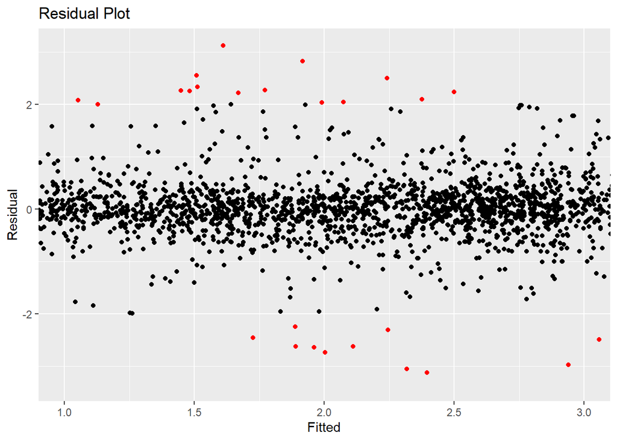

```r
res <- resid(final_model)
data.frame(fitted = fitted(final_model), res) %>%
  ggplot()+
  aes(fitted, res, color = abs(res)>2)+
  geom_point()+
  coord_cartesian(xlim = c(1,3))+
  theme(legend.position = "None")+
  labs(y = "Residual", x = "Fitted", title = "Residual Plot")+
  scale_color_manual(values=c("black", "red"))
```

```r
stargazer(final_model$finalModel,
          title = "Multiple Linear Model",
          align = TRUE,
          type = "latex",
          out="table1.doc")
```

[output not shown]

[output cut: 48 more lines]

```
##   & \\
##  Constant & 1.563^{***} \\
##   & (0.010) \\
##   & \\
## \hline \\[-1.8ex]
## Observations & \multicolumn{1}{c}{3,067} \\
## R$^{2}$ & \multicolumn{1}{c}{0.818} \\
## Adjusted R$^{2}$ & \multicolumn{1}{c}{0.817} \\
## Residual Std. Error & \multicolumn{1}{c}{0.550 (df = 3041)} \\
## F Statistic & \multicolumn{1}{c}{546.927$^{***}$ (df = 25; 3041)} \\
## \hline
## \hline \\[-1.8ex]
## \textit{Note:}  & \multicolumn{1}{r}{$^{*}$p$<$0.1; $^{**}$p$<$0.05; $^{***}$p$<$0.01} \\
## \end{tabular}
## \end{table}
```

```r
preds_finalmodel <-  final_model %>%
  predict(test_data,type = "raw")
round((cor(preds_finalmodel,test_data$Pop_growth))^2,2)
```

```
## [1] 0.78
```

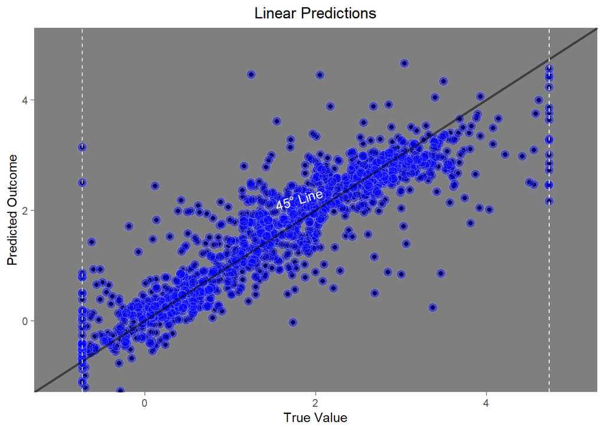

```r
ggplot(data.frame(test_data$Pop_growth,preds_finalmodel))+
  aes(test_data.Pop_growth,preds_finalmodel)+
  geom_point()+
  theme_dark()+
  geom_point(shape = 21, size = 3.5, fill = "blue", color = "white", alpha = 0.4)+
  theme(panel.grid = element_blank(),
        plot.title = element_text(hjust = 0.5))+
  labs(title = "Linear Predictions")+
  geom_abline(slope = 1, intercept = 0, color = "black", size = 1, alpha = 0.5)+
  labs(y = "Predicted Outcome", x = "True Value")+
  annotate("text", x = 1.8, y = 2.2, label = "45° Line", color = "White", angle = 17)+
  coord_cartesian(xlim = c(-1,5), ylim = c(-1,5))+
  geom_vline(xintercept = c(lower_bound,upper_bound), color = "white", linetype = 2)
```